# IE582 - HW4

Ufuk Üstündağ

29 January 2021

```r
library(readxl)
library(data.table)
library(glmnet)
```

```r
library(ggplot2)
library(dplyr)
library(tidyverse)
library(Information)
library(caTools)
library(rpart)
library(rattle)
library(randomForest)
library(gbm)
```

# TASK 1

```r
datapath1 = 'C:/Users/busra/Desktop/IE 582/Data1_frogs.xlsx'
data1 = read_excel(datapath1)
data1 = as.data.frame(data1)

datapath2 = 'C:/Users/busra/Desktop/IE 582/Data2_superconductivity.xlsx'
data2 = read_excel(datapath2)
data2 = as.data.frame(data2)

datapath3 = 'C:/Users/busra/Desktop/IE 582/Data3_parkinson.xlsx'
data3 = read_excel(datapath3)
data3 = as.data.frame(data3)

datapath4 = 'C:/Users/busra/Desktop/IE 582/Data4_miceprotein.xlsx'
data4 = read_excel(datapath4)
data4 = as.data.frame(data4)

perf_dt=function(actual,forecast){
  n=length(actual)
  error=actual-forecast
  mean=mean(actual)
  sd=sd(actual)
  FBias=sum(error)/sum(actual)
  MPE=sum(error/actual)/n
  MAPE=sum(abs(error/actual))/n
  RMSE=sqrt(sum(error^2))/n
  MAD=sum(abs(error))/n
  WMAPE=MAD/mean
  l=data.frame(n,mean,sd,FBias,MAPE,RMSE,MAD,WMAPE)
  return(l)
}
```

# TASK 2

## PENALIZED REGRESSION 1

```r
unique(data1$Species)
```

```
##  [1] "AdenomeraAndre"         "Ameeregatrivittata"     "AdenomeraHylaedactylus"
##  [4] "HylaMinuta"             "HypsiboasCinerascens"   "HypsiboasCordobae"
##  [7] "LeptodactylusFuscus"    "OsteocephalusOophagus"  "Rhinellagranulosa"
## [10] "ScinaxRuber"
```

```r
data1_reworked = data1[,-c(23,24,26)]

Species_num <- vector()
for(i in 1:length(data1$Species))
{
  if(data1$Species[i] == "AdenomeraAndre"){Species_num[i] = 1}
  else{Species_num[i] = 0}
}
# class imbalance

data1_reworked$Species = Species_num

set.seed(100)
spl1 = sample.split(data1_reworked$Species, SplitRatio = 0.8)
Train1 = subset(data1_reworked,spl1==TRUE)
Test1 = subset(data1_reworked,spl1==FALSE)

feature_matrix1 = as.matrix(Train1[,1:22])
target1 = Train1$Species

set.seed(100)
cvfit1 = cv.glmnet(feature_matrix1, target1, family = 'binomial')
cvfit1
```

```
##
## Call:  cv.glmnet(x = feature_matrix1, y = target1, family = "binomial")
##
## Measure: Binomial Deviance
##
##        Lambda Index Measure      SE Nonzero
## min 0.0001133    79 0.08518 0.01018      20
## 1se 0.0009631    56 0.09444 0.00853      17
```

```r
print(coef(cvfit1, s = 'lambda.1se'))
```

```
## 23 x 1 sparse Matrix of class "dgCMatrix"
##                       1
## (Intercept)  -7.9368963
## MFCCs_ 1      3.9092497
## MFCCs_ 2      0.6468691
## MFCCs_ 3      1.4972798
## MFCCs_ 4     -6.5701888
## MFCCs_ 5      1.5739993
## MFCCs_ 6     -8.1377807
## MFCCs_ 7      8.4944530
## MFCCs_ 8      .
## MFCCs_ 9      .
## MFCCs_10      4.4767364
## MFCCs_11     11.6763761
## MFCCs_12    -11.9137451
## MFCCs_13      .
## MFCCs_14      0.9868605
## MFCCs_15      5.6771640
## MFCCs_16      .
## MFCCs_17      2.3047310
## MFCCs_18    -12.3456323
## MFCCs_19     -3.9698904
## MFCCs_20     -3.6103162
## MFCCs_21      .
## MFCCs_22      8.2933914
```

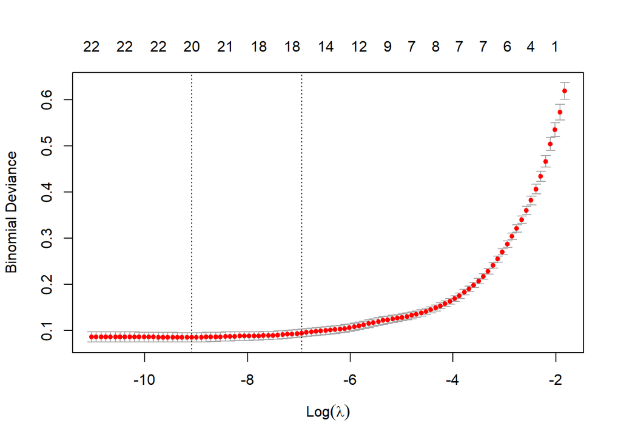

```r
plot(cvfit1)
```

```r
pred1.1 <- predict(cvfit1, as.matrix(Test1[,1:22]), s = c("lambda.1se"), type="class")
perf_dt(Test1$Species, as.numeric(as.vector(pred1.1)))
```

```
##      n       mean        sd      FBias MAPE        RMSE        MAD     WMAPE
## 1 1439 0.09312022 0.2907019 0.04477612  NaN 0.002948326 0.01250869 0.1343284
```

## PENALIZED REGRESSION 2

```r
set.seed(100)
spl2 = sample.split(data2$critical_temp, SplitRatio = 0.8)
Train2 = subset(data2,spl2==TRUE)
Test2 = subset(data2,spl2==FALSE)

feature_matrix2 = as.matrix(Train2[,1:(ncol(Train2)-1)])
target2 = Train2$critical_temp

set.seed(100)
cvfit2 = cv.glmnet(feature_matrix2, target2, family = 'gaussian')
cvfit2
```

```
##
## Call:  cv.glmnet(x = feature_matrix2, y = target2, family = "gaussian")
##
## Measure: Mean-Squared Error
##
##       Lambda Index Measure    SE Nonzero
## min 0.002481   100   312.2 2.668      75
## 1se 0.009125    86   314.7 2.921      74
```

```r
print(coef(cvfit2, s = 'lambda.1se'))
```

```
## 82 x 1 sparse Matrix of class "dgCMatrix"
##                                             1
## (Intercept)                     -1.822818e+01
## number_of_elements              -4.231704e+00
## mean_atomic_mass                 3.093718e-01
## wtd_mean_atomic_mass            -2.237850e-01
## gmean_atomic_mass               -3.110408e-05
## wtd_gmean_atomic_mass            .
## entropy_atomic_mass             -3.345709e+01
## wtd_entropy_atomic_mass          8.135436e+00
## range_atomic_mass                1.761041e-01
## wtd_range_atomic_mass            3.442675e-03
## std_atomic_mass                 -1.820069e-01
## wtd_std_atomic_mass             -2.333819e-01
## mean_fie                         7.642029e-03
## wtd_mean_fie                     1.414311e-02
## gmean_fie                        .
## wtd_gmean_fie                    .
## entropy_fie                      .
## wtd_entropy_fie                  2.951308e+01
## range_fie                        6.272502e-02
## wtd_range_fie                    1.937300e-02
## std_fie                         -1.505133e-01
## wtd_std_fie                     -2.834840e-02
## mean_atomic_radius               7.164217e-01
## wtd_mean_atomic_radius           6.410592e-01
## gmean_atomic_radius             -9.719173e-01
## wtd_gmean_atomic_radius         -3.143647e-01
## entropy_atomic_radius            .
## wtd_entropy_atomic_radius        2.801247e+01
## range_atomic_radius              2.041329e-01
## wtd_range_atomic_radius         -9.124714e-02
## std_atomic_radius               -8.724590e-01
## wtd_std_atomic_radius            3.890620e-01
## mean_Density                    -3.468125e-03
## wtd_mean_Density                -3.875624e-04
## gmean_Density                    1.441395e-04
## wtd_gmean_Density                2.359685e-03
## entropy_Density                  1.298464e+01
## wtd_entropy_Density             -1.779562e+01
```

[output cut: 29 more lines]

```
## wtd_entropy_ThermalConductivity  5.901165e+00
## range_ThermalConductivity       -3.832367e-02
## wtd_range_ThermalConductivity   -1.929839e-01
## std_ThermalConductivity          9.692772e-02
## wtd_std_ThermalConductivity      5.363433e-02
## mean_Valence                     .
## wtd_mean_Valence                 .
## gmean_Valence                    2.425193e+00
## wtd_gmean_Valence               -2.901905e+00
## entropy_Valence                  3.141055e+01
## wtd_entropy_Valence             -4.420795e+01
## range_Valence                    4.225584e+00
## wtd_range_Valence                1.337822e+00
## std_Valence                     -2.276218e-01
## wtd_std_Valence                 -1.871902e+01
```

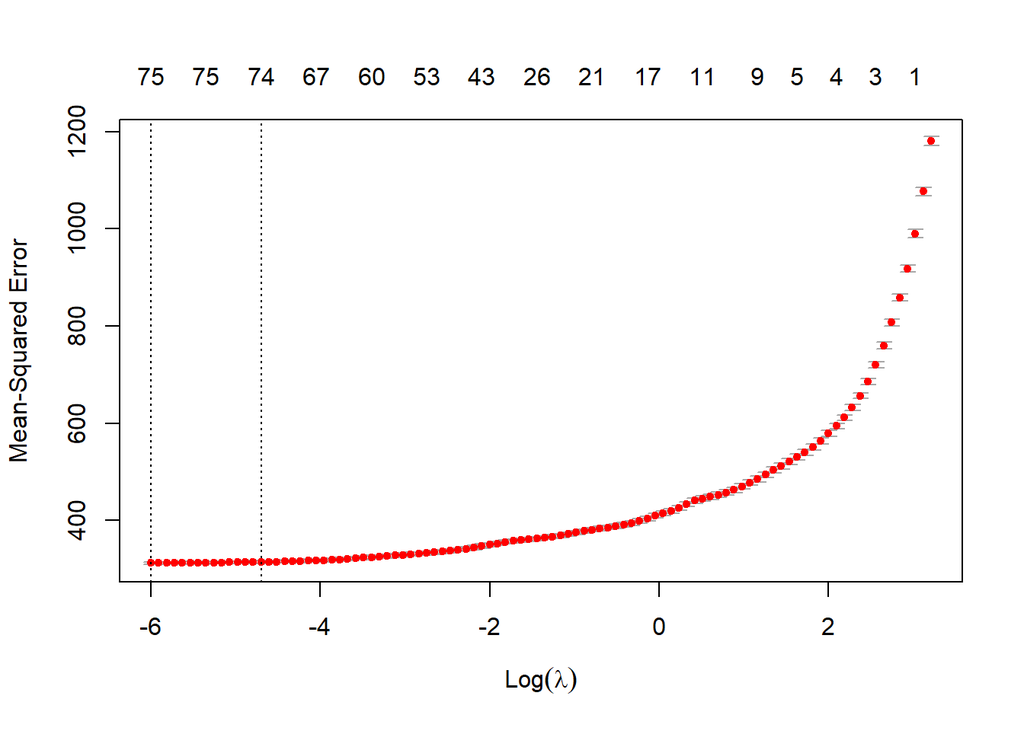

```r
plot(cvfit2)
```

```r
pred1.2 <- predict(cvfit2, as.matrix(Test2[,1:(ncol(Test2)-1)]), s = c("lambda.1se"))
perf_dt(Test2$critical_temp, pred1.2)
```

```
##      n     mean       sd        FBias     MAPE     RMSE      MAD     WMAPE
## 1 3973 34.46426 33.73183 -0.002171391 9.019062 0.281807 13.46213 0.3906114
```

## PENALIZED REGRESSION 3

```r
set.seed(100)
spl3 = sample.split(data3$PPE, SplitRatio = 0.8)
Train3 = subset(data3,spl3==TRUE)
Test3 = subset(data3,spl3==FALSE)

feature_matrix3 = as.matrix(Train3[,1:(ncol(Train3)-1)])
target3 = Train3$PPE

set.seed(100)
cvfit3 = cv.glmnet(feature_matrix3, target3, family = 'gaussian')
cvfit3
```

```
##
## Call:  cv.glmnet(x = feature_matrix3, y = target3, family = "gaussian")
##
## Measure: Mean-Squared Error
##
##        Lambda Index  Measure        SE Nonzero
## min 0.0000201    89 0.001895 4.504e-05      20
## 1se 0.0003945    57 0.001938 3.834e-05      18
```

```r
print(coef(cvfit3, s = 'lambda.1se'))
```

```
## 22 x 1 sparse Matrix of class "dgCMatrix"
##                           1
## (Intercept)    2.181446e-01
## subject#       2.580279e-05
## age            3.665906e-04
## sex            1.513281e-03
## test_time      1.118594e-05
## motor_UPDRS    7.755523e-04
## total_UPDRS   -1.447931e-04
## Jitter(%)      1.234982e+01
## Jitter(Abs)    1.005292e+03
## Jitter:RAP    -1.562853e+01
## Jitter:PPQ5    .
## Jitter:DDP    -3.315753e-02
## Shimmer        .
## Shimmer(dB)    1.245230e-01
## Shimmer:APQ3  -1.657088e+00
## Shimmer:APQ5  -7.845333e-01
## Shimmer:APQ11  3.876998e-01
## Shimmer:DDA    .
## NHR           -3.179437e-01
## HNR           -8.325468e-03
## RPDE           1.341259e-02
## DFA            1.047426e-01
```

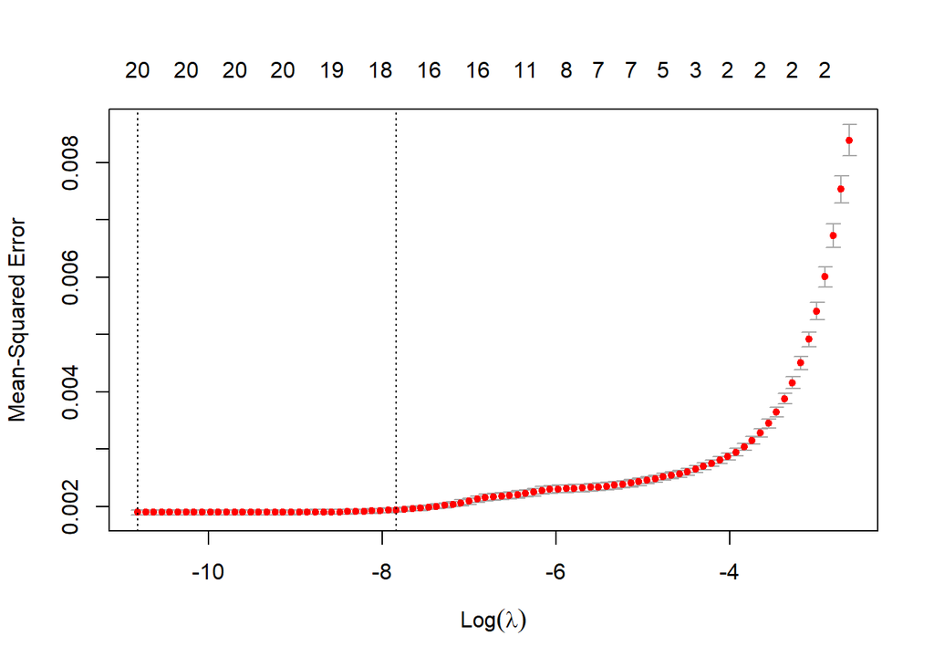

```r
plot(cvfit3)
```

```r
pred1.3 <- predict(cvfit3, as.matrix(Test3[,1:(ncol(Test3)-1)]), s = c("lambda.1se"))
perf_dt(Test3$PPE, pred1.3)
```

```
##      n      mean        sd        FBias      MAPE        RMSE        MAD
## 1 1175 0.2199294 0.0906427 -0.002290466 0.1707749 0.001291895 0.03361039
##       WMAPE
## 1 0.1528235
```

## PENALIZED REGRESSION 4

```r
unique(data4$class)
```

```
## [1] "c-CS-m" "c-SC-m" "c-CS-s" "c-SC-s" "t-CS-m" "t-SC-m" "t-CS-s" "t-SC-s"
```

```r
class_num <- vector()
for(i in 1:length(data4$class))
{
  if(data4$class[i] == "c-CS-m"){class_num[i] = 1}
  if(data4$class[i] == "c-SC-m"){class_num[i] = 2}
  if(data4$class[i] == "c-CS-s"){class_num[i] = 3}
  if(data4$class[i] == "c-SC-s"){class_num[i] = 4}
  if(data4$class[i] == "t-CS-m"){class_num[i] = 5}
  if(data4$class[i] == "t-SC-m"){class_num[i] = 6}
  if(data4$class[i] == "t-CS-s"){class_num[i] = 7}
  if(data4$class[i] == "t-SC-s"){class_num[i] = 8}
}

data4_reworked = data4
data4_reworked$class = class_num

set.seed(100)
spl4 = sample.split(data4_reworked$class, SplitRatio = 0.8)
Train4 = subset(data4_reworked,spl4==TRUE)
Test4 = subset(data4_reworked,spl4==FALSE)

feature_matrix4 = as.matrix(Train4[,2:67])
target4 = Train4$class

set.seed(100)
cvfit4 = cv.glmnet(feature_matrix4, target4, family = 'gaussian')
cvfit4
```

```
##
## Call:  cv.glmnet(x = feature_matrix4, y = target4, family = "gaussian")
##
## Measure: Mean-Squared Error
##
##      Lambda Index Measure      SE Nonzero
## min 0.00408    60   1.234 0.06977      59
## 1se 0.01246    48   1.295 0.07215      53
```

```r
print(coef(cvfit4, s = 'lambda.1se'))
```

```
## 67 x 1 sparse Matrix of class "dgCMatrix"
##                           1
## (Intercept)       4.5167433
## DYRK1A_N          .
## ITSN1_N           1.3241704
## BDNF_N           -3.8253055
## NR1_N             .
## NR2A_N           -0.5515910
## pAKT_N            6.9789196
## pBRAF_N          -1.4292444
## pCAMKII_N         0.1823122
## pCREB_N           8.5231762
## pELK_N           -0.3548260
## pERK_N            .
## pJNK_N           -8.9680333
## PKCA_N           -5.6797626
## pMEK_N            .
## pNR1_N           -1.1734156
## pNR2A_N          -2.0755104
## pNR2B_N           1.9696929
## pPKCAB_N         -0.3588749
## pRSK_N           -2.5883784
## AKT_N             5.3221514
## BRAF_N           -0.5148205
## CAMKII_N         -0.7395262
## CREB_N            .
## ERK_N            -0.4800203
## GSK3B_N          -1.8540952
## JNK_N            -2.4158955
## TRKA_N            3.5514782
## RSK_N            -6.2484178
## APP_N            16.6550421
## SOD1_N            0.9098354
## MTOR_N            0.3590036
## P38_N            -0.3932188
## pMTOR_N           .
## DSCR1_N           2.3624315
## AMPKA_N         -14.9427202
## NR2B_N           -4.5374199
## pNUMB_N          -7.3321601
```

[output cut: 14 more lines]

```
## ERBB4_N           5.4339219
## nNOS_N          -12.0112724
## Tau_N            10.5164208
## GFAP_N            7.8608626
## GluR3_N         -11.8903363
## GluR4_N           .
## IL1B_N           -9.3855117
## P3525_N           9.5916104
## pCASP9_N          2.1159593
## PSD95_N           .
## SNCA_N            .
## Ubiquitin_N      -0.3285695
## pGSK3B_Tyr216_N  -1.8126269
## SHH_N             .
## CaNA_N            .
```

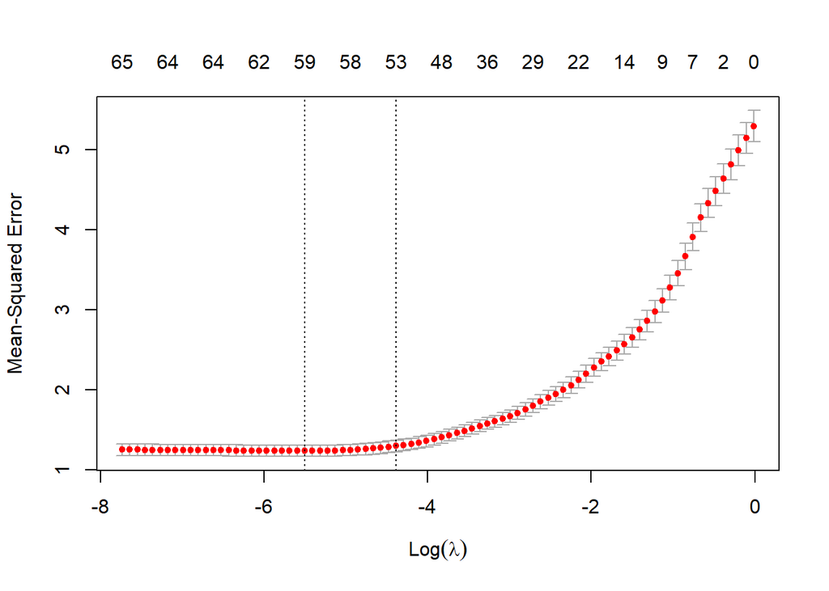

```r
plot(cvfit4)
```

```r
pred1.4 <- predict(cvfit4, as.matrix(Test4[,2:67]), s = c("lambda.1se"))
perf_dt(Test4$class, pred1.4)
```

```
##     n     mean       sd        FBias      MAPE       RMSE       MAD    WMAPE
## 1 215 4.330233 2.301517 -0.006163762 0.2954458 0.06725188 0.7809923 0.180358
```

### performances

```r
perf1.1 <- perf_dt(Test1$Species, as.numeric(as.vector(pred1.1)))[8]
perf1.2 <- perf_dt(Test2$critical_temp, pred1.2)[8]
perf1.3 <- perf_dt(Test3$PPE, pred1.3)[8]
perf1.4 <- perf_dt(Test4$class, pred1.4)[8]
penal_reg_all <- c(perf1.1, perf1.2, perf1.3, perf1.4)
```

## DECISION TREE 1

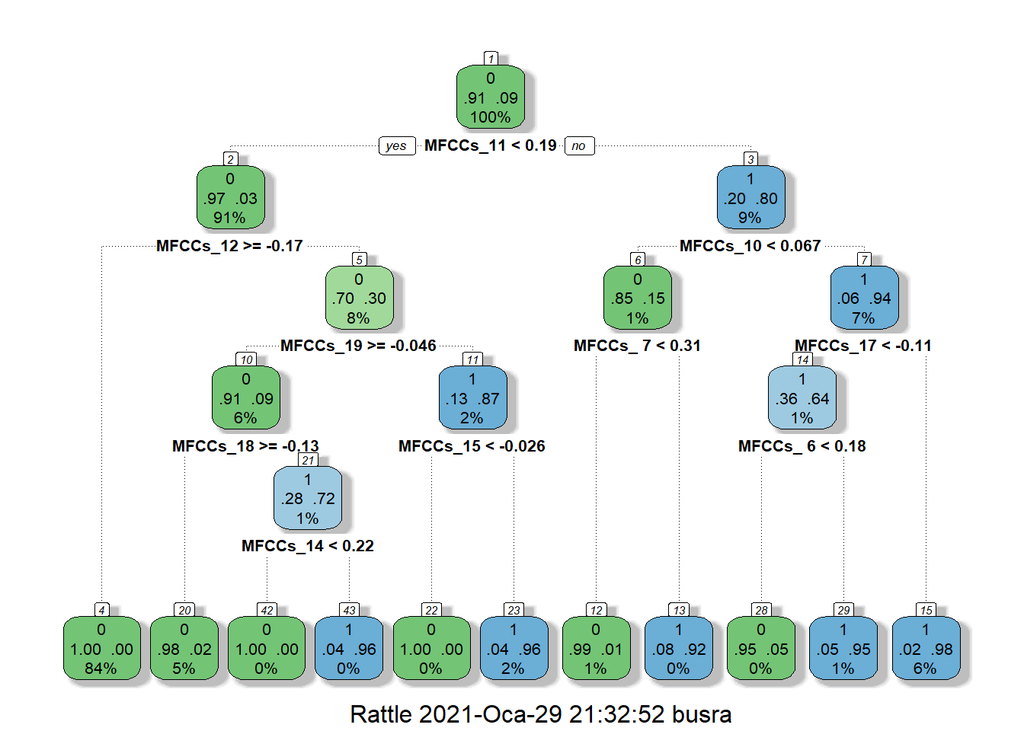

```r
data1_reworked = data1[,-c(23,24,26)]

Species_num <- vector()
for(i in 1:length(data1$Species))
{
  if(data1$Species[i] == "AdenomeraAndre"){Species_num[i] = 1}
  else{Species_num[i] = 0}
}
# class imbalance

data1_reworked$Species = Species_num

set.seed(100)
spl1 = sample.split(data1_reworked$Species, SplitRatio = 0.8)
Train1 = subset(data1_reworked,spl1==TRUE)
Test1 = subset(data1_reworked,spl1==FALSE)

tree1 = rpart(Species~., Train1, method='class')
fancyRpartPlot(tree1)
```

```r
tree1$variable.importance
```

```
##  MFCCs_11  MFCCs_ 9  MFCCs_ 7  MFCCs_19  MFCCs_12  MFCCs_10  MFCCs_13  MFCCs_ 5
## 538.34784 233.16770 225.00954 141.89617 128.28717 107.89452 102.79983 100.28209
##  MFCCs_16  MFCCs_18  MFCCs_14  MFCCs_ 4  MFCCs_21  MFCCs_ 6  MFCCs_15  MFCCs_17
##  70.33016  69.55403  65.63743  47.46936  45.98434  35.30955  33.17320  30.85547
##  MFCCs_ 3  MFCCs_20  MFCCs_ 8  MFCCs_ 1  MFCCs_ 2
##  28.99624  14.38903  12.65417  10.05025   4.73115
```

```r
pred2.1 <- predict(tree1, Test1, type="class")
perf_dt(Test1$Species, as.numeric(as.vector(pred2.1)))
```

```
##      n       mean        sd      FBias MAPE        RMSE        MAD     WMAPE
## 1 1439 0.09312022 0.2907019 0.06716418  NaN 0.002865258 0.01181376 0.1268657
```

## DECISION TREE 2

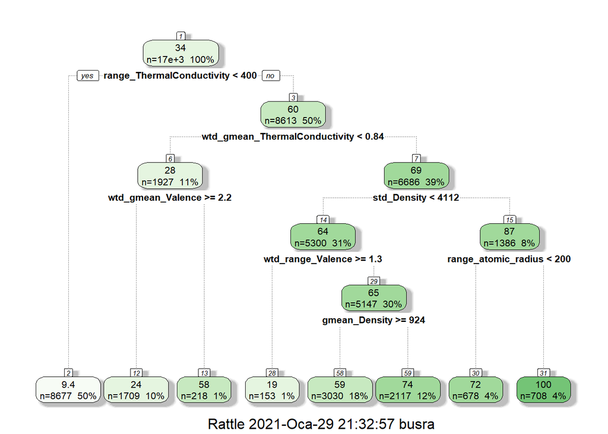

```r
set.seed(100)
spl2 = sample.split(data2$critical_temp, SplitRatio = 0.8)
Train2 = subset(data2,spl2==TRUE)
Test2 = subset(data2,spl2==FALSE)

tree2 = rpart(critical_temp~., Train2)
fancyRpartPlot(tree2)
```

```r
tree2$variable.importance
```

```
##     range_ThermalConductivity   wtd_std_ThermalConductivity
##                    10864510.3                    10477258.0
##       std_ThermalConductivity             wtd_gmean_Valence
##                    10404096.3                     9949424.8
##              wtd_mean_Valence           range_atomic_radius
##                     9834747.6                     9691911.3
## wtd_gmean_ThermalConductivity          wtd_gmean_FusionHeat
##                     2506459.5                     2022597.0
##  wtd_mean_ThermalConductivity    wtd_range_ElectronAffinity
##                     1977072.3                     1817085.6
##                 wtd_range_fie             wtd_gmean_Density
##                     1814484.2                     1758553.8
##                   std_Density               wtd_std_Valence
##                      561716.1                      455988.4
##                 range_Density      wtd_std_ElectronAffinity
##                      455533.1                      347440.2
##               std_atomic_mass             wtd_range_Valence
##                      329086.2                      320871.4
##                 gmean_Density               wtd_std_Density
##                      288370.1                      284910.8
##                     range_fie               entropy_Density
##                      268595.2                      266303.1
##           entropy_atomic_mass             std_atomic_radius
##                      228571.1                      213080.0
##                  mean_Density               entropy_Valence
##                      211555.4                      198603.5
##      entropy_ElectronAffinity                 gmean_Valence
##                      196015.4                      177566.7
##         entropy_atomic_radius                  mean_Valence
##                      174493.2                      173892.9
##  wtd_entropy_ElectronAffinity         wtd_range_atomic_mass
##                      160258.7                      142609.5
##     wtd_mean_ElectronAffinity          wtd_mean_atomic_mass
##                      121755.0                      111151.5
```

```r
pred2.2 <- predict(tree2,Test2)
perf_dt(Test2$critical_temp, pred2.2)
```

```
##      n     mean       sd       FBias     MAPE      RMSE      MAD     WMAPE
## 1 3973 34.46426 33.73183 -0.00557922 9.739511 0.2853954 12.95919 0.3760184
```

## DECISION TREE 3

[figure not shown]

```r
set.seed(100)
spl3 = sample.split(data3$PPE, SplitRatio = 0.8)
Train3 = subset(data3,spl3==TRUE)
Test3 = subset(data3,spl3==FALSE)

tree3 = rpart(PPE~., Train3)
fancyRpartPlot(tree3)
```

```r
tree3$variable.importance
```

```
##  Jitter:PPQ5    Jitter(%)   Jitter:DDP   Jitter:RAP  Jitter(Abs)          NHR
## 27.837614142 23.848918799 20.763968363 20.744632557 17.469442113 10.998914785
##          HNR         RPDE
##  0.898228884  0.008336929
```

```r
pred2.3 <- predict(tree3,Test3)
perf_dt(Test3$PPE, pred2.3)
```

```
##      n      mean        sd       FBias      MAPE        RMSE        MAD
## 1 1175 0.2199294 0.0906427 0.008693976 0.1763624 0.001378654 0.03525133
##       WMAPE
## 1 0.1602848
```

## DECISION TREE 4

[figure not shown]

```r
class_num <- vector()
for(i in 1:length(data4$class))
{
  if(data4$class[i] == "c-CS-m"){class_num[i] = 1}
  if(data4$class[i] == "c-SC-m"){class_num[i] = 2}
  if(data4$class[i] == "c-CS-s"){class_num[i] = 3}
  if(data4$class[i] == "c-SC-s"){class_num[i] = 4}
  if(data4$class[i] == "t-CS-m"){class_num[i] = 5}
  if(data4$class[i] == "t-SC-m"){class_num[i] = 6}
  if(data4$class[i] == "t-CS-s"){class_num[i] = 7}
  if(data4$class[i] == "t-SC-s"){class_num[i] = 8}
}

data4_reworked = data4[2:67]
data4_reworked$class = class_num

set.seed(100)
spl4 = sample.split(data4_reworked$class, SplitRatio = 0.8)
Train4 = subset(data4_reworked,spl4==TRUE)
Test4 = subset(data4_reworked,spl4==FALSE)

tree4 = rpart(class~., Train4, method='class')
fancyRpartPlot(tree4)
```

```r
tree4$variable.importance
```

```
##         pPKCG_N          SOD1_N     Ubiquitin_N        DYRK1A_N           APP_N
##      165.710631      127.856620      115.070529      113.016638       91.282414
##          CaNA_N          pERK_N          BRAF_N            S6_N         ITSN1_N
##       90.142422       87.201226       83.024547       66.061838       62.468197
##        pPKCAB_N       pCAMKII_N         pNUMB_N        pGSK3B_N         GSK3B_N
##       60.912533       50.958027       49.181548       40.013270       35.236121
##          pRSK_N        RAPTOR_N          TRKA_N         DSCR1_N          MTOR_N
##       33.504846       31.338052       31.308941       30.173844       29.974173
##         AMPKA_N           AKT_N          NUMB_N         P3525_N        pP70S6_N
##       28.233114       27.202850       25.706073       23.793528       22.976902
##          PKCA_N           ARC_N        pCASP9_N         P70S6_N           BAX_N
##       22.439191       20.462552       19.913983       18.320794       17.494756
##          NR2B_N         pMTOR_N         pNR2A_N          RRP1_N         TIAM1_N
##       17.465266       16.993232       16.157423       15.986366       15.760922
##           Tau_N           P38_N         ERBB4_N         PSD95_N         pNR2B_N
##       15.474617       15.341112       15.186263       15.098894       14.481284
##    AcetylH3K9_N          pMEK_N         pCREB_N           NR1_N           RSK_N
##       14.398558       14.225922       13.990908       13.644444       13.539500
##          nNOS_N          CDK5_N          pNR1_N          IL1B_N          CREB_N
##       13.513968       10.000124        9.551111        8.922222        7.953216
## pGSK3B_Tyr216_N         pBRAF_N          pAKT_N           JNK_N          GFAP_N
##        7.845996        6.959064        5.027655        4.970760        4.469027
##           ERK_N
##        4.439171
```

```r
pred2.4 <- predict(tree4,Test4,type='class')
perf_dt(Test4$class, as.numeric(as.vector(pred2.4)))
```

```
##     n     mean       sd       FBias      MAPE      RMSE       MAD     WMAPE
## 1 215 4.330233 2.301517 0.002148228 0.3162791 0.1207512 0.8837209 0.2040816
```

### performances

```r
perf2.1 <- perf_dt(Test1$Species, as.numeric(as.vector(pred2.1)))[8]
perf2.2 <- perf_dt(Test2$critical_temp, pred2.2)[8]
perf2.3 <- perf_dt(Test3$PPE, pred2.3)[8]
perf2.4 <- perf_dt(Test4$class, as.numeric(as.vector(pred2.4)))[8]
dec_tree_all <- c(perf2.1, perf2.2, perf2.3, perf2.4)
```

## RANDOM FOREST 1

```r
data1_reworked = data1[,-c(23,24,26)]

Species_num <- vector()
for(i in 1:length(data1$Species))
{
  if(data1$Species[i] == "AdenomeraAndre"){Species_num[i] = 1}
  else{Species_num[i] = 0}
}
# class imbalance

data1_reworked$Species = Species_num
data1_reworked$Species = as.factor(data1_reworked$Species)

set.seed(100)
spl1 = sample.split(data1_reworked$Species, SplitRatio = 0.8)
Train1 = subset(data1_reworked,spl1==TRUE)
Test1 = subset(data1_reworked,spl1==FALSE)

forest1 = randomForest(Train1[,-ncol(Train1)], Train1$Species)
forest1
```

```
##
## Call:
##  randomForest(x = Train1[, -ncol(Train1)], y = Train1$Species)
##                Type of random forest: classification
##                      Number of trees: 500
## No. of variables tried at each split: 4
##
##         OOB estimate of  error rate: 0.31%
## Confusion matrix:
##      0   1 class.error
## 0 5212   6 0.001149866
## 1   12 526 0.022304833
```

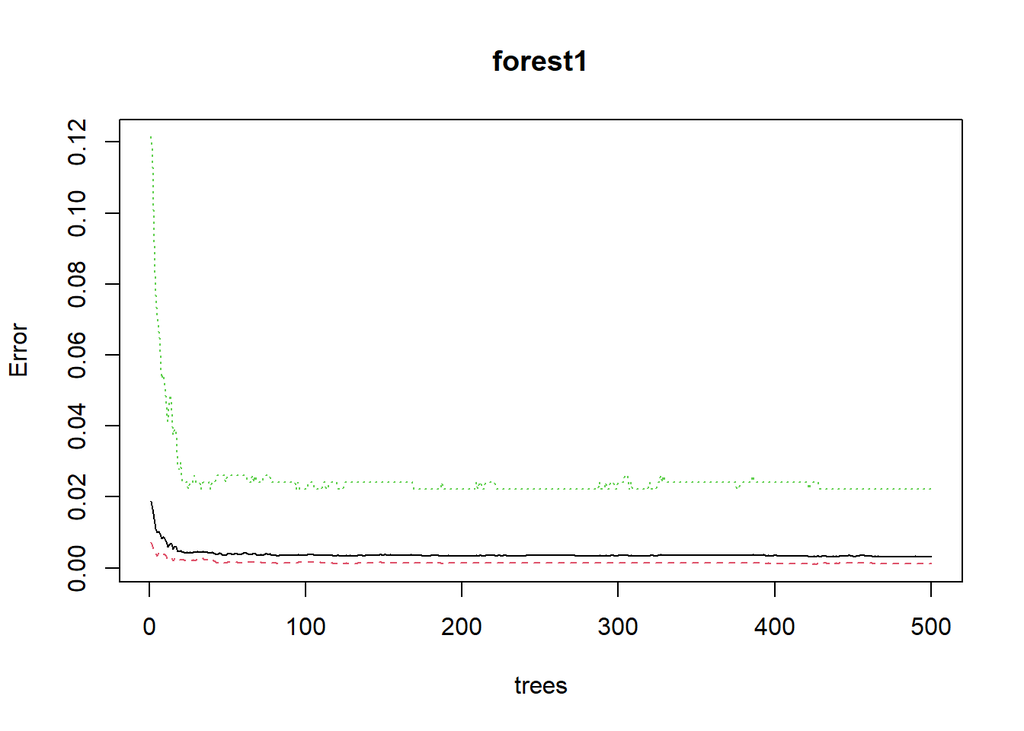

```r
plot(forest1)
```

```r
pred3.1 <- predict(forest1, Test1)
perf_dt(as.numeric(as.vector(Test1$Species)), as.numeric(as.vector(pred3.1)))
```

```
##      n       mean        sd      FBias MAPE       RMSE         MAD      WMAPE
## 1 1439 0.09312022 0.2907019 0.04477612  NaN 0.00196555 0.005559416 0.05970149
```

## RANDOM FOREST 2

```r
set.seed(100)
spl2 = sample.split(data2$critical_temp, SplitRatio = 0.8)
Train2 = subset(data2,spl2==TRUE)
Test2 = subset(data2,spl2==FALSE)

forest2 = randomForest(Train2[,-ncol(Train2)], Train2$critical_temp, ntree = 50)
forest2
```

```
##
## Call:
##  randomForest(x = Train2[, -ncol(Train2)], y = Train2$critical_temp,      ntree = 50)
##                Type of random forest: regression
##                      Number of trees: 50
## No. of variables tried at each split: 27
##
##           Mean of squared residuals: 90.85891
##                     % Var explained: 92.31
```

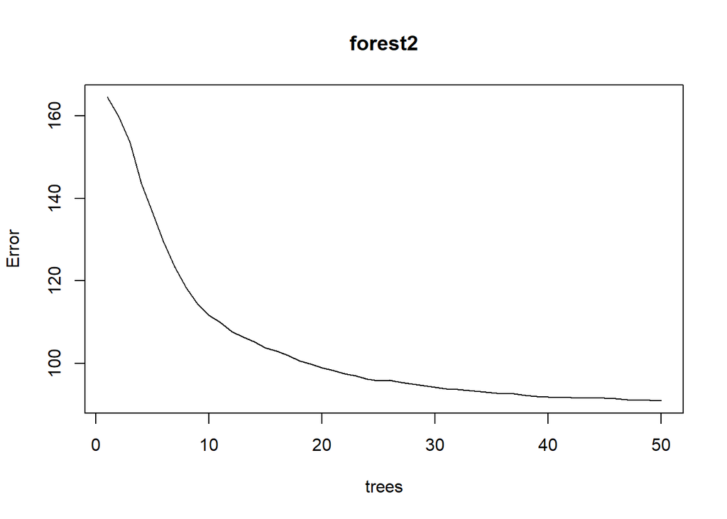

```r
plot(forest2)
```

```r
pred3.2 <- predict(forest2, Test2)
perf_dt(Test2$critical_temp, as.vector(pred3.2))
```

```
##      n     mean       sd        FBias     MAPE      RMSE      MAD     WMAPE
## 1 3973 34.46426 33.73183 -0.003430903 4.004345 0.1471467 5.326049 0.1545384
```

## RANDOM FOREST 3

```r
set.seed(100)
spl3 = sample.split(data3$PPE, SplitRatio = 0.8)
Train3 = subset(data3,spl3==TRUE)
Test3 = subset(data3,spl3==FALSE)

forest3 = randomForest(Train3[,-ncol(Train3)], Train3$PPE)
forest3
```

```
##
## Call:
##  randomForest(x = Train3[, -ncol(Train3)], y = Train3$PPE)
##                Type of random forest: regression
##                      Number of trees: 500
## No. of variables tried at each split: 7
##
##           Mean of squared residuals: 0.001257108
##                     % Var explained: 85.05
```

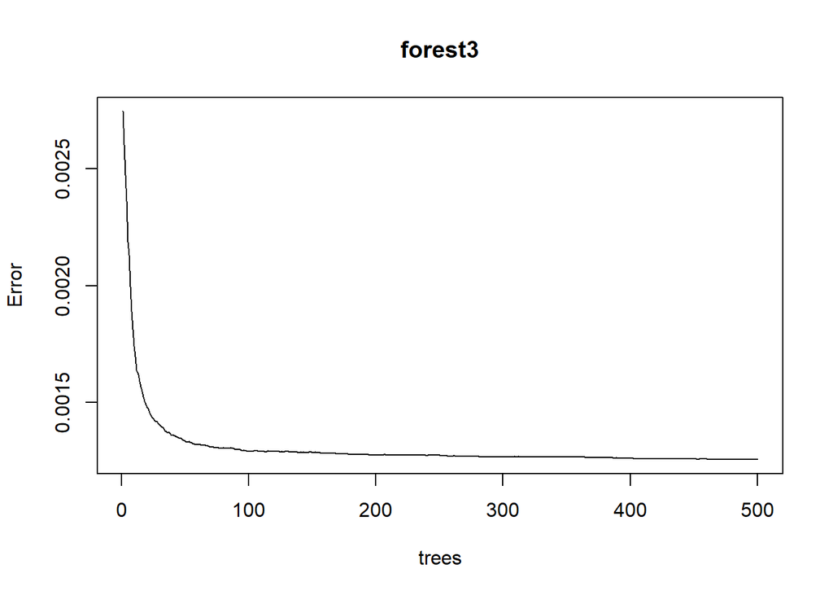

```r
plot(forest3)
```

```r
pred3.3 <- predict(forest3, Test3)
perf_dt(Test3$PPE, as.vector(pred3.3))
```

```
##      n      mean        sd       FBias      MAPE        RMSE        MAD
## 1 1175 0.2199294 0.0906427 0.002450005 0.1278471 0.001024795 0.02548441
##       WMAPE
## 1 0.1158754
```

## RANDOM FOREST 4

```r
class_num <- vector()
for(i in 1:length(data4$class))
{
  if(data4$class[i] == "c-CS-m"){class_num[i] = 1}
  if(data4$class[i] == "c-SC-m"){class_num[i] = 2}
  if(data4$class[i] == "c-CS-s"){class_num[i] = 3}
  if(data4$class[i] == "c-SC-s"){class_num[i] = 4}
  if(data4$class[i] == "t-CS-m"){class_num[i] = 5}
  if(data4$class[i] == "t-SC-m"){class_num[i] = 6}
  if(data4$class[i] == "t-CS-s"){class_num[i] = 7}
  if(data4$class[i] == "t-SC-s"){class_num[i] = 8}
}

data4_reworked = data4[2:67]
data4_reworked$class = as.factor(class_num)

set.seed(100)
spl4 = sample.split(data4_reworked$class, SplitRatio = 0.8)
Train4 = subset(data4_reworked,spl4==TRUE)
Test4 = subset(data4_reworked,spl4==FALSE)

forest4 = randomForest(Train4[,-ncol(Train4)], Train4$class)
forest4
```

```
##
## Call:
##  randomForest(x = Train4[, -ncol(Train4)], y = Train4$class)
##                Type of random forest: classification
##                      Number of trees: 500
## No. of variables tried at each split: 8
##
##         OOB estimate of  error rate: 0.7%
## Confusion matrix:
##     1   2   3   4   5   6  7   8 class.error
## 1 120   0   0   0   0   0  0   0 0.000000000
## 2   0 119   0   0   0   1  0   0 0.008333333
## 3   3   0 105   0   0   0  0   0 0.027777778
## 4   0   0   0 108   0   0  0   0 0.000000000
## 5   0   0   0   0 107   0  1   0 0.009259259
## 6   0   1   0   0   0 107  0   0 0.009259259
## 7   0   0   0   0   0   0 84   0 0.000000000
## 8   0   0   0   0   0   0  0 106 0.000000000
```

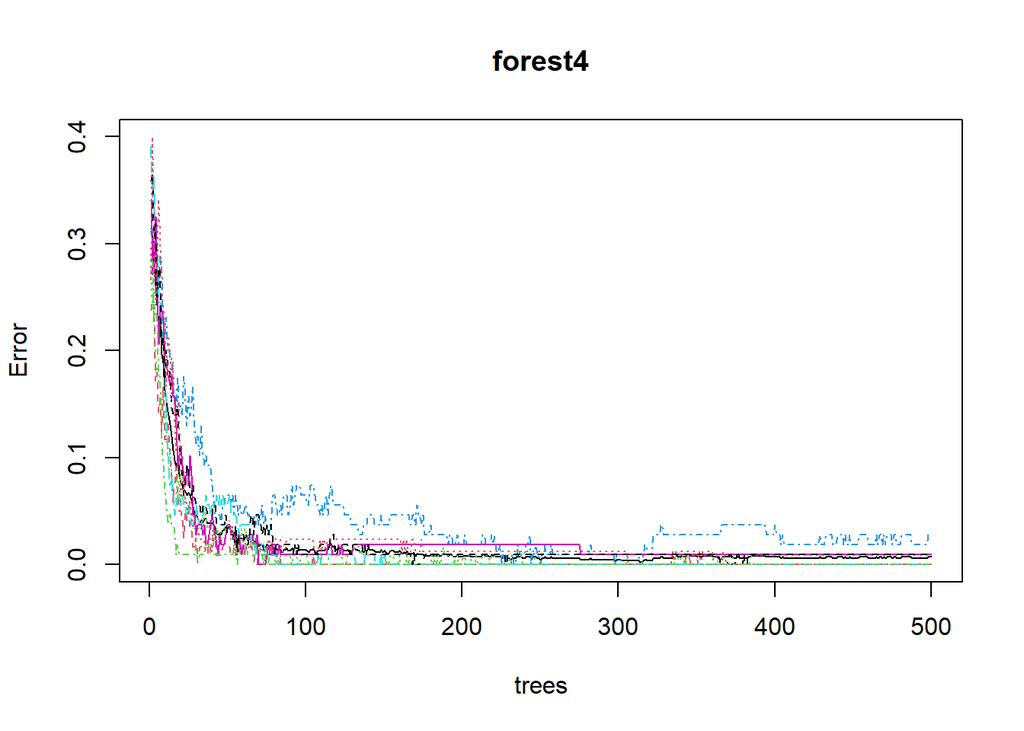

```r
plot(forest4)
```

```r
pred3.4 <- predict(forest4, Test4)
perf_dt(as.numeric(as.vector(Test4$class)), as.numeric(as.vector(pred3.4)))
```

```
##     n     mean       sd FBias MAPE RMSE MAD WMAPE
## 1 215 4.330233 2.301517     0    0    0   0     0
```

### performances

```r
perf3.1 <- perf_dt(as.numeric(as.vector(Test1$Species)), as.numeric(as.vector(pred3.1)))[8]
perf3.2 <- perf_dt(Test2$critical_temp, as.vector(pred3.2))[8]
perf3.3 <- perf_dt(Test3$PPE, as.vector(pred3.3))[8]
perf3.4 <- perf_dt(as.numeric(as.vector(Test4$class)), as.numeric(as.vector(pred3.4)))[8]
rand_forest_all <- c(perf3.1, perf3.2, perf3.3, perf3.4)
```

## GRADIENT BOOSTING 1

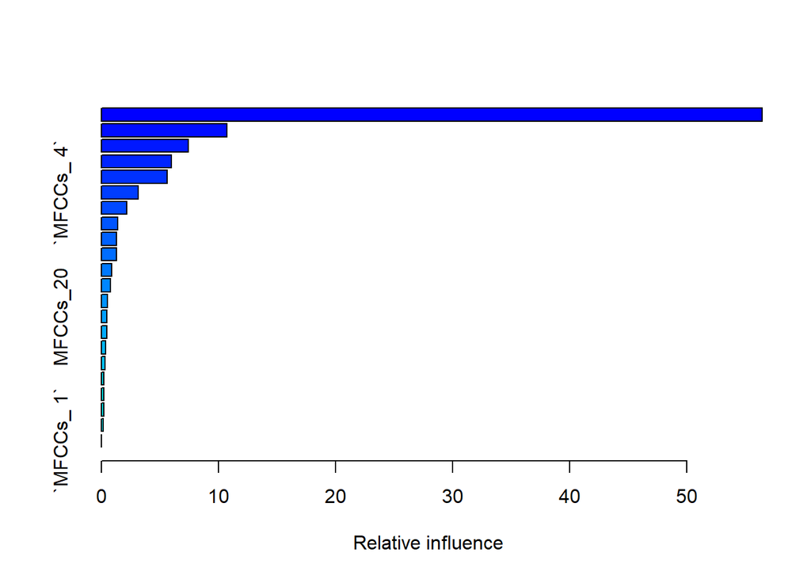

```
##                   var    rel.inf
## MFCCs_11     MFCCs_11 56.4239307
## MFCCs_12     MFCCs_12 10.7152835
## MFCCs_18     MFCCs_18  7.4452040
## MFCCs_10     MFCCs_10  5.9962799
## MFCCs_19     MFCCs_19  5.6253594
## `MFCCs_ 4` `MFCCs_ 4`  3.1549556
## `MFCCs_ 6` `MFCCs_ 6`  2.1456955
## MFCCs_15     MFCCs_15  1.4118811
## MFCCs_17     MFCCs_17  1.2939183
## `MFCCs_ 9` `MFCCs_ 9`  1.2702585
## `MFCCs_ 8` `MFCCs_ 8`  0.8662355
## MFCCs_21     MFCCs_21  0.7738125
## `MFCCs_ 7` `MFCCs_ 7`  0.4954132
## MFCCs_20     MFCCs_20  0.4731874
## MFCCs_13     MFCCs_13  0.4681751
## MFCCs_22     MFCCs_22  0.3525026
## `MFCCs_ 5` `MFCCs_ 5`  0.2978481
## MFCCs_16     MFCCs_16  0.2256539
## `MFCCs_ 3` `MFCCs_ 3`  0.1920436
## MFCCs_14     MFCCs_14  0.1912924
## `MFCCs_ 2` `MFCCs_ 2`  0.1810691
## `MFCCs_ 1` `MFCCs_ 1`  0.0000000
```

```r
data1_reworked = data1[,-c(23,24,26)]

Species_num <- vector()
for(i in 1:length(data1$Species))
{
  if(data1$Species[i] == "AdenomeraAndre"){Species_num[i] = 1}
  else{Species_num[i] = 0}
}
# class imbalance

data1_reworked$Species = as.numeric(Species_num)

set.seed(100)
spl1 = sample.split(data1_reworked$Species, SplitRatio = 0.8)
Train1 = subset(data1_reworked,spl1==TRUE)
Test1 = subset(data1_reworked,spl1==FALSE)

gradboost1 = gbm(Species~., data=Train1, distribution = "bernoulli", n.trees = 200, shrinkage = 0.01, interaction.depth = 10, cv.folds = 10)
summary(gradboost1)
```

```r
pred4.1 <- round(predict(gradboost1, Test1, type="response"))
```

```
## Using 200 trees...
```

```r
perf_dt(Test1$Species, as.vector(pred4.1))
```

```
##      n       mean        sd    FBias MAPE        RMSE        MAD    WMAPE
## 1 1439 0.09312022 0.2907019 0.119403  NaN 0.002779708 0.01111883 0.119403
```

## GRADIENT BOOSTING 2

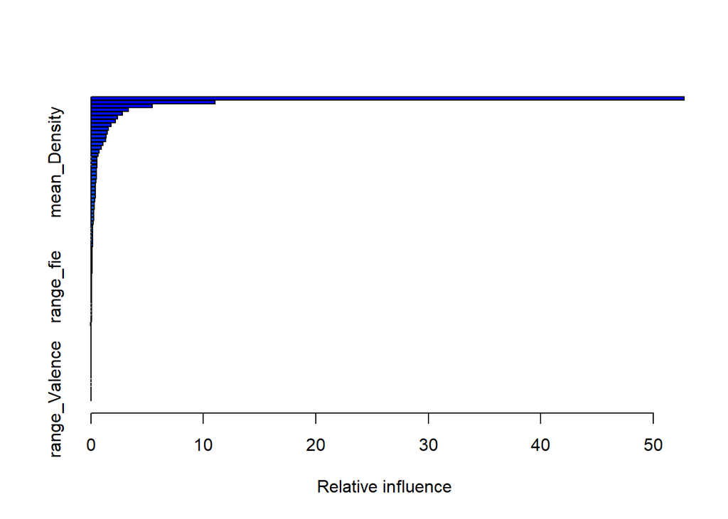

```
##                                                             var     rel.inf
## range_ThermalConductivity             range_ThermalConductivity 52.75230273
## wtd_gmean_ThermalConductivity     wtd_gmean_ThermalConductivity 11.04745487
## range_atomic_radius                         range_atomic_radius  5.45836881
## wtd_entropy_atomic_mass                 wtd_entropy_atomic_mass  3.32233642
## wtd_entropy_Valence                         wtd_entropy_Valence  2.79121022
## wtd_std_ElectronAffinity               wtd_std_ElectronAffinity  2.35751299
## wtd_gmean_Valence                             wtd_gmean_Valence  2.18592408
## std_atomic_mass                                 std_atomic_mass  1.77256943
## wtd_mean_ThermalConductivity       wtd_mean_ThermalConductivity  1.55975607
## wtd_entropy_ThermalConductivity wtd_entropy_ThermalConductivity  1.47214418
## std_Density                                         std_Density  1.36023272
## wtd_std_ThermalConductivity         wtd_std_ThermalConductivity  1.30486430
## wtd_mean_Valence                               wtd_mean_Valence  1.08438456
## gmean_ElectronAffinity                   gmean_ElectronAffinity  0.94060084
## gmean_Density                                     gmean_Density  0.71055036
## wtd_gmean_ElectronAffinity           wtd_gmean_ElectronAffinity  0.61673289
## wtd_std_Valence                                 wtd_std_Valence  0.54596560
## mean_Density                                       mean_Density  0.51758889
## wtd_mean_atomic_mass                       wtd_mean_atomic_mass  0.51650879
## wtd_range_atomic_mass                     wtd_range_atomic_mass  0.49330206
## wtd_range_Valence                             wtd_range_Valence  0.48981242
## std_ElectronAffinity                       std_ElectronAffinity  0.48227087
## gmean_Valence                                     gmean_Valence  0.42414851
## mean_ThermalConductivity               mean_ThermalConductivity  0.39467137
## wtd_entropy_Density                         wtd_entropy_Density  0.38414573
## wtd_entropy_ElectronAffinity       wtd_entropy_ElectronAffinity  0.37137899
## wtd_range_fie                                     wtd_range_fie  0.37090816
## wtd_std_atomic_mass                         wtd_std_atomic_mass  0.34594903
## wtd_entropy_fie                                 wtd_entropy_fie  0.31843773
## std_atomic_radius                             std_atomic_radius  0.31058816
## wtd_entropy_FusionHeat                   wtd_entropy_FusionHeat  0.23811016
## wtd_std_Density                                 wtd_std_Density  0.23078045
## wtd_entropy_atomic_radius             wtd_entropy_atomic_radius  0.22565393
## wtd_gmean_atomic_mass                     wtd_gmean_atomic_mass  0.21559087
## wtd_mean_Density                               wtd_mean_Density  0.17292243
## wtd_mean_atomic_radius                   wtd_mean_atomic_radius  0.17282730
## wtd_gmean_Density                             wtd_gmean_Density  0.17264735
## entropy_ThermalConductivity         entropy_ThermalConductivity  0.15369058
## wtd_std_FusionHeat                           wtd_std_FusionHeat  0.13164423
```

[output cut: 27 more lines]

```
## gmean_fie                                             gmean_fie  0.01531356
## mean_atomic_mass                               mean_atomic_mass  0.01452085
## mean_Valence                                       mean_Valence  0.01447893
## gmean_atomic_radius                         gmean_atomic_radius  0.01415659
## std_Valence                                         std_Valence  0.01263855
## range_FusionHeat                               range_FusionHeat  0.00497055
## gmean_ThermalConductivity             gmean_ThermalConductivity  0.00474938
## number_of_elements                           number_of_elements  0.00000000
## gmean_atomic_mass                             gmean_atomic_mass  0.00000000
## entropy_atomic_mass                         entropy_atomic_mass  0.00000000
## std_fie                                                 std_fie  0.00000000
## range_Density                                     range_Density  0.00000000
## wtd_range_FusionHeat                       wtd_range_FusionHeat  0.00000000
## entropy_Valence                                 entropy_Valence  0.00000000
## range_Valence                                     range_Valence  0.00000000
```

```r
set.seed(100)
spl2 = sample.split(data2$critical_temp, SplitRatio = 0.8)
Train2 = subset(data2,spl2==TRUE)
Test2 = subset(data2,spl2==FALSE)

gradboost2 = gbm(critical_temp~., data=Train2, distribution = "gaussian", n.trees = 200, shrinkage = 0.01, interaction.depth = 10, cv.folds = 10)
summary(gradboost2)
```

```r
pred4.2 <- predict(gradboost2, Test2)
```

```
## Using 200 trees...
```

```r
perf_dt(Test2$critical_temp, as.vector(pred4.2))
```

```
##      n     mean       sd        FBias     MAPE      RMSE      MAD     WMAPE
## 1 3973 34.46426 33.73183 -0.001823183 10.06972 0.2358264 11.42521 0.3315089
```

## GRADIENT BOOSTING 3

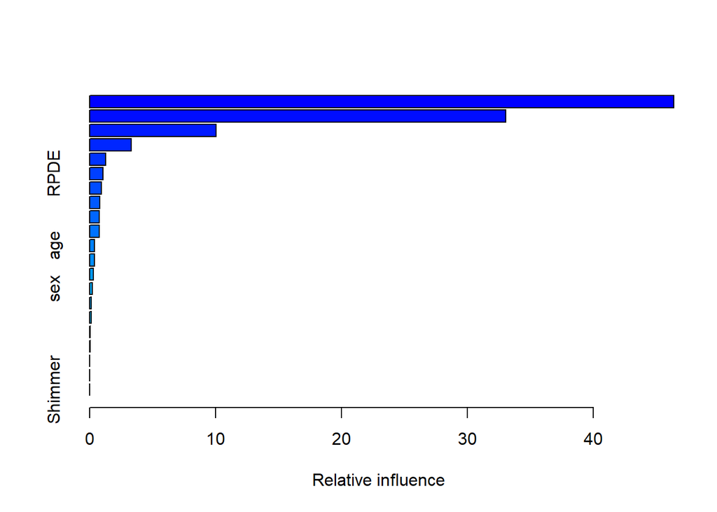

```
##                             var      rel.inf
## `Jitter:PPQ5`     `Jitter:PPQ5` 46.373682102
## `Jitter(%)`         `Jitter(%)` 33.022029698
## `Jitter(Abs)`     `Jitter(Abs)` 10.028340784
## HNR                         HNR  3.311585899
## `Shimmer:APQ11` `Shimmer:APQ11`  1.263794813
## RPDE                       RPDE  1.066465579
## `subject#`           `subject#`  0.939595962
## NHR                         NHR  0.827926595
## motor_UPDRS         motor_UPDRS  0.774290553
## DFA                         DFA  0.765204922
## age                         age  0.386362403
## total_UPDRS         total_UPDRS  0.383835012
## `Shimmer:APQ3`   `Shimmer:APQ3`  0.286060663
## sex                         sex  0.202346385
## `Jitter:RAP`       `Jitter:RAP`  0.143589673
## `Jitter:DDP`       `Jitter:DDP`  0.123296317
## `Shimmer(dB)`     `Shimmer(dB)`  0.033670308
## `Shimmer:APQ5`   `Shimmer:APQ5`  0.032853475
## test_time             test_time  0.014894122
## `Shimmer:DDA`     `Shimmer:DDA`  0.012641188
## Shimmer                 Shimmer  0.007533545
```

```r
set.seed(100)
spl3 = sample.split(data3$PPE, SplitRatio = 0.8)
Train3 = subset(data3,spl3==TRUE)
Test3 = subset(data3,spl3==FALSE)

gradboost3 = gbm(PPE~., data=Train3, distribution = "gaussian", n.trees = 200, shrinkage = 0.01, interaction.depth = 10, cv.folds = 10)
summary(gradboost3)
```

```r
pred4.3 <- predict(gradboost3, Test3)
```

```
## Using 200 trees...
```

```r
perf_dt(Test3$PPE, as.vector(pred4.3))
```

```
##      n      mean        sd       FBias      MAPE        RMSE       MAD    WMAPE
## 1 1175 0.2199294 0.0906427 0.005047291 0.1574252 0.001208654 0.0304776 0.138579
```

## GRADIENT BOOSTING 4

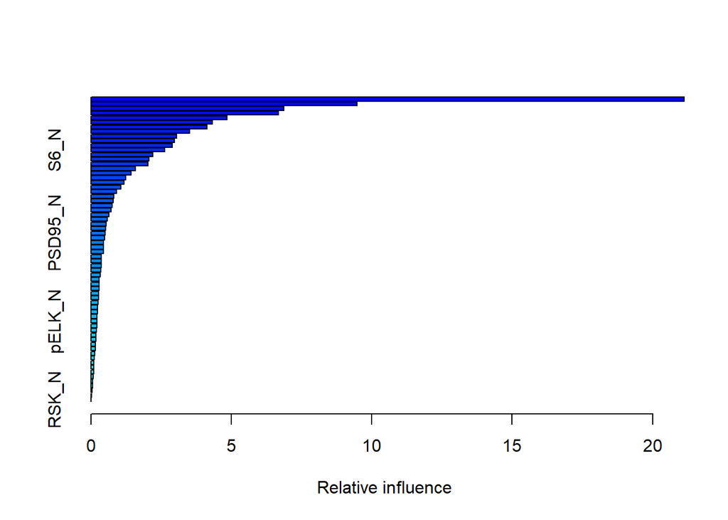

```
##                             var     rel.inf
## APP_N                     APP_N 21.12404310
## Tau_N                     Tau_N  9.46948137
## pPKCG_N                 pPKCG_N  6.86193881
## SOD1_N                   SOD1_N  6.68126482
## AMPKA_N                 AMPKA_N  4.84305246
## AcetylH3K9_N       AcetylH3K9_N  4.32484165
## BRAF_N                   BRAF_N  4.12656161
## GluR3_N                 GluR3_N  3.50865035
## pNUMB_N                 pNUMB_N  3.04339392
## P38_N                     P38_N  2.97113218
## pERK_N                   pERK_N  2.88752361
## S6_N                       S6_N  2.62865838
## RRP1_N                   RRP1_N  2.19576768
## GSK3B_N                 GSK3B_N  2.06610549
## PKCA_N                   PKCA_N  2.02245504
## CaNA_N                   CaNA_N  1.58403177
## pMTOR_N                 pMTOR_N  1.43007640
## NR2A_N                   NR2A_N  1.23221088
## ITSN1_N                 ITSN1_N  1.18068368
## ARC_N                     ARC_N  1.05946062
## NR2B_N                   NR2B_N  0.90837044
## pJNK_N                   pJNK_N  0.80948912
## pP70S6_N               pP70S6_N  0.79623118
## BDNF_N                   BDNF_N  0.75124705
## pCAMKII_N             pCAMKII_N  0.72011928
## pGSK3B_N               pGSK3B_N  0.64015186
## MTOR_N                   MTOR_N  0.57321640
## BAX_N                     BAX_N  0.53504645
## Ubiquitin_N         Ubiquitin_N  0.51633209
## PSD95_N                 PSD95_N  0.50258210
## ADARB1_N               ADARB1_N  0.49132952
## ERBB4_N                 ERBB4_N  0.45085349
## pNR2A_N                 pNR2A_N  0.44935498
## pPKCAB_N               pPKCAB_N  0.43706727
## NR1_N                     NR1_N  0.37605479
## DYRK1A_N               DYRK1A_N  0.37290504
## RAPTOR_N               RAPTOR_N  0.35972354
## CDK5_N                   CDK5_N  0.34303065
## ERK_N                     ERK_N  0.32127486
```

[output cut: 12 more lines]

```
## pNR2B_N                 pNR2B_N  0.17526313
## TIAM1_N                 TIAM1_N  0.16822871
## JNK_N                     JNK_N  0.15008446
## DSCR1_N                 DSCR1_N  0.14788620
## GFAP_N                   GFAP_N  0.13275800
## pCASP9_N               pCASP9_N  0.11199219
## P70S6_N                 P70S6_N  0.10157647
## SNCA_N                   SNCA_N  0.09388499
## CAMKII_N               CAMKII_N  0.09183126
## TRKA_N                   TRKA_N  0.07720346
## pNR1_N                   pNR1_N  0.06379439
## pGSK3B_Tyr216_N pGSK3B_Tyr216_N  0.05648671
## pBRAF_N                 pBRAF_N  0.04792998
## CREB_N                   CREB_N  0.02703799
## RSK_N                     RSK_N  0.00000000
```

```r
class_num <- vector()
for(i in 1:length(data4$class))
{
  if(data4$class[i] == "c-CS-m"){class_num[i] = 1}
  if(data4$class[i] == "c-SC-m"){class_num[i] = 2}
  if(data4$class[i] == "c-CS-s"){class_num[i] = 3}
  if(data4$class[i] == "c-SC-s"){class_num[i] = 4}
  if(data4$class[i] == "t-CS-m"){class_num[i] = 5}
  if(data4$class[i] == "t-SC-m"){class_num[i] = 6}
  if(data4$class[i] == "t-CS-s"){class_num[i] = 7}
  if(data4$class[i] == "t-SC-s"){class_num[i] = 8}
}

data4_reworked = data4[2:67]
data4_reworked$class = as.factor(class_num)

set.seed(100)
spl4 = sample.split(data4_reworked$class, SplitRatio = 0.8)
Train4 = subset(data4_reworked,spl4==TRUE)
Test4 = subset(data4_reworked,spl4==FALSE)

gradboost4 = gbm(class~., data=Train4, distribution = "gaussian", n.trees = 200, shrinkage = 0.01, interaction.depth = 10, cv.folds = 10)
summary(gradboost4)
```

```r
pred4.4 <- predict(gradboost4, Test4)
```

```
## Using 200 trees...
```

```r
pred4.4 <- pred4.4/(max(pred4.4)-min(pred4.4))*7
pred4.4 <- pred4.4 - (min(pred4.4)-1)
pred4.4 <- round(pred4.4)

perf_dt(as.numeric(Test4$class), pred4.4)
```

```
##     n     mean       sd       FBias      MAPE       RMSE       MAD     WMAPE
## 1 215 4.330233 2.301517 -0.01933405 0.2471207 0.05956395 0.5581395 0.1288937
```

### performances

```r
perf4.1 <- perf_dt(Test1$Species, as.vector(pred4.1))[8]
perf4.2 <- perf_dt(Test2$critical_temp, as.vector(pred4.2))[8]
perf4.3 <- perf_dt(Test3$PPE, as.vector(pred4.3))[8]
perf4.4 <- perf_dt(as.numeric(Test4$class), pred4.4)[8]
grad_boost_all <- c(perf4.1, perf4.2, perf4.3, perf4.4)
```

# Performance Analysis

```r
perf_all <- data.frame(as.numeric(penal_reg_all), as.numeric(dec_tree_all), as.numeric(rand_forest_all), as.numeric(grad_boost_all))
perf_all
```

```
##   as.numeric.penal_reg_all. as.numeric.dec_tree_all.
## 1                 0.1343284                0.1268657
## 2                 0.3906114                0.3760184
## 3                 0.1528235                0.1602848
## 4                 0.1803580                0.2040816
##   as.numeric.rand_forest_all. as.numeric.grad_boost_all.
## 1                  0.05970149                  0.1194030
## 2                  0.15453835                  0.3315089
## 3                  0.11587541                  0.1385790
## 4                  0.00000000                  0.1288937
```

For penalized regression approach, different values for the parameter lambda could be tried and WMAPE values could be compared for further analysis

For the decision trees, increasing the complexity parameter or the minimumnumber of observations per tree leaf would probably improve the overall performance of this method, however, this would make computation harder.

The random forest method best in terms of WMAPE in general, when compared to the other 3 methods. Similar to the decision tree increasing the complexity parameter, the minimumnumber of observations per tree leaf or the number of trees per forest would probably improve the overall performance of this method, however, this would make computation harder.

The boosted decision trees gave better performance measures than the regular decision trees. However, the computation time was increased. For further analysis similar parameters and the learning rate in addition could be changed.